# HW2-EDA with R - Part1: Plotting

misken

January 22, 2018

## Step 1 - Familiarize yourself with the data and the assignment

In this assignment you’ll do some exploratory data analysis with R on a dataset US census information based on the [American Community Survey](https://www.census.gov/programs-surveys/acs/). The version of this data that we’ll be using is from a Kaggle dataset. See https://www.kaggle.com/muonneutrino/us-census-demographic-data/data and look at the column metadata for the county level table to see what the various columns mean.

As we did in class, you’ll be creating an R Markdown document to both prepare a dataset and do some analysis as well as to document the steps you did (and answer some questions I’ll throw at you).

You’ll notice a few “Hacker Extra” tasks thrown in. These are for those of you who want to go a little above and beyond and attempt some more challenging tasks. And, feel free to do a some free form Hacker Extra style work yourself - in other words, do something beyond what was asked. You’ll learn more.

## Step 2 - Create a new R Markdown document

Save this file as a new R Markdown document and name it **HW2_EDAwR_[*your last name*].Rmd**. Mine would be called **HW2_EDAwR_isken.Rmd**. Save it into the same folder as this file.

This will be your working directory.

Create a new R Project based on this working directory.

**Hacker Extra** - Put this project folder under version control using git. Only track the .R file, the .Rmd file and your .gitignore file. Create a remote repo for this homework assignment in your GitHub account. Periodically push your commits to GitHub. When done with the assignment, paste in the URL of your GitHub project so that I can go look at it.

https://github.com/ankitaguhaoakland/hw2_files

## Step 3 - Set working directory and explore data folder

Set the working directory or create an R Studio project in the current folder. You’ll notice that there is a folder named **data**. Inside of it you’ll find the data files for this assignment:

- **acs2015_census_tract_data.csv**
- **acs2015_county_data.csv**
- **us_census_bureau_regions_and_divisions.csv**
- **county.csv**
- **county_MI.csv**

The first two files are from the Kaggle site for this dataset. The two files, **county.csv** and **county_MI.csv**, are files that I created. The first contains county level data from all states and the other just data from Michigan. The R script, **census_data_prep.R** was used to create these files and to merge information from the **us_census_bureau_regions_and_divisions.csv** file with the county data.

You might want to use shell commands or a text editor like Geany to snoop the files a bit.

## Step 4 - Complete the following R tasks and answer questions

Now you’ll need to complete the following tasks in R. Just like we did in class, you should use a combination of markdown text (be concise, no need to write tons of text) to explain what you are doing and R code chunks to actually do it. When you are done, use the “Knit” button to generate an HTML file from your R Markdown. You’ll be submitting BOTH the completed R Markdown file as well as the generated HTML file. You’ll notice that I’ve left some empty code chunks as well as some partially filled in code chunks. Of course, feel free to add more code chunks as needed.

Let’s load a few libraries we’ll need:

```r
library(dplyr)
```

```r
library(ggplot2)
```

### Problem 1 - Get the data into a dataframe

You should read the **county.csv** file into a data frame named county_df and **county_MI.csv** into a data frame named county_MI.

```r
county_df <- read.table("data/county.csv", header=TRUE, sep=",", stringsAsFactors=FALSE)
county_MI <- read.table("data/county_MI.csv", header=TRUE, sep=",", stringsAsFactors=FALSE)
```

Check the structure of each data.frame and use the `summary` function to begin exploring the data. Are there any NA values? What differences do you notice between the structure of the two data frames. # Structure of Data Frame county_df

```r
str(county_df)
```

```
## 'data.frame':    3142 obs. of  40 variables:
##  $ State          : chr  "Alabama" "Alabama" "Alabama" "Alabama" ...
##  $ CensusId       : int  1055 1133 1053 1001 1003 1005 1007 1009 1011 1013 ...
##  $ State.Code     : chr  "AL" "AL" "AL" "AL" ...
##  $ Region         : chr  "South" "South" "South" "South" ...
##  $ Division       : chr  "East South Central" "East South Central" "East South Central" "East South Central" ...
##  $ County         : chr  "Etowah" "Winston" "Escambia" "Autauga" ...
##  $ TotalPop       : int  103766 24130 37935 55221 195121 26932 22604 57710 10678 20354 ...
##  $ Men            : int  50207 11876 19524 26745 95314 14497 12073 28512 5660 9502 ...
##  $ Women          : int  53559 12254 18411 28476 99807 12435 10531 29198 5018 10852 ...
##  $ Hispanic       : num  3.6 2.8 1.2 2.6 4.5 4.6 2.2 8.6 4.4 1.2 ...
##  $ White          : num  78.5 94.3 60.7 75.8 83.1 46.2 74.5 87.9 22.2 53.3 ...
##  $ Black          : num  15.4 0.5 33.4 18.5 9.5 46.7 21.4 1.5 70.7 43.8 ...
##  $ Native         : num  0.3 0.3 3.2 0.4 0.6 0.2 0.4 0.3 1.2 0.1 ...
##  $ Asian          : num  0.7 0.2 0.1 1 0.7 0.4 0.1 0.1 0.2 0.4 ...
```

[output cut: 26 more lines]

# Structure of Data Frame county_MI

```r
str(county_MI)
```

```
## 'data.frame':    83 obs. of  41 variables:
##  $ County         : chr  "Alcona" "Alger" "Allegan" "Alpena" ...
##  $ peninsula      : chr  "LP" "UP" "LP" "LP" ...
##  $ State          : chr  "Michigan" "Michigan" "Michigan" "Michigan" ...
##  $ CensusId       : int  26001 26003 26005 26007 26009 26011 26013 26015 26017 26019 ...
##  $ State.Code     : chr  "MI" "MI" "MI" "MI" ...
##  $ Region         : chr  "Midwest" "Midwest" "Midwest" "Midwest" ...
##  $ Division       : chr  "East North Central" "East North Central" "East North Central" "East North Central" ...
##  $ TotalPop       : int  10550 9476 112837 29068 23267 15424 8690 59147 106698 17437 ...
##  $ Men            : int  5310 5218 56205 14276 11587 7813 5265 29733 52513 8708 ...
##  $ Women          : int  5240 4258 56632 14792 11680 7611 3425 29414 54185 8729 ...
##  $ Hispanic       : num  1.4 1.3 7 1.2 1.9 1.8 1.3 2.5 5 2.1 ...
##  $ White          : num  96.3 84.8 89.1 96.1 95.2 95.2 73.3 94.9 90.6 94.3 ...
##  $ Black          : num  0.3 7.7 1.4 0.5 0.3 0.5 18.3 0.5 1.3 0.3 ...
##  $ Native         : num  0.2 2.6 0.5 0.6 0.9 1.3 4.5 0.2 0.2 1.2 ...
```

[output cut: 27 more lines]

The county_MI data frame contains data for Michigan only and includes an peninsula field. See **census_data_prep.R** to see how this field was created. It involves scraping a table out of a web page.

Unless otherwise specified, you should use the ggplot2 package for all of the following plots.

### Problem 2 - Basic plots for Income

Create a histogram, boxplot, kernel density plot and violin plot for median income for the entire US.

Write a short paragraph describing the distribution of median incomes.

From the Boxplot, it can be said that, the Median Income for the entire US is closer to the lower end of the spectrum of all the values and is closer to the end of the left whiskers (down whiskers) than to that of the end of the right whisker (top whiskers). The Median income for the entire US is along the mid line of the box, starting a little below 50,000 and we can approximate the same as around $ 45,000.

From both the Kernel Density Plot as well as the Violin plot we can see that the spread of the Income for the entire US is topping and buldging respectively somehwere around 45,000.

# Histogram

```r
median_income <- median(county_df$Income, na.rm = TRUE)
median_income
```

```
## [1] 45111
```

```r
mean_income <- median(county_df$Income, na.rm = TRUE)
mean_income
```

```
## [1] 45111
```

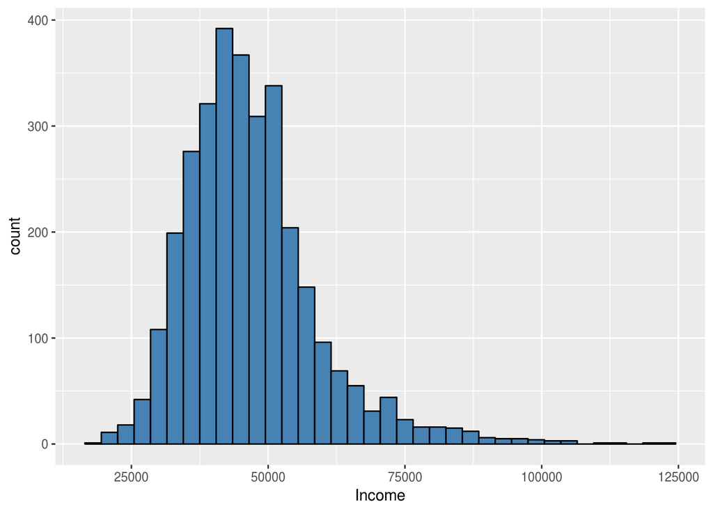

```r
library(ggplot2)
ggplot(data = county_df) +
  geom_histogram(aes(x = Income), binwidth = 3000, fill = "steelblue", colour="Black")
```

# BoxPlot

There needs to be some value corresposnding to x aesthetic, so used 1.

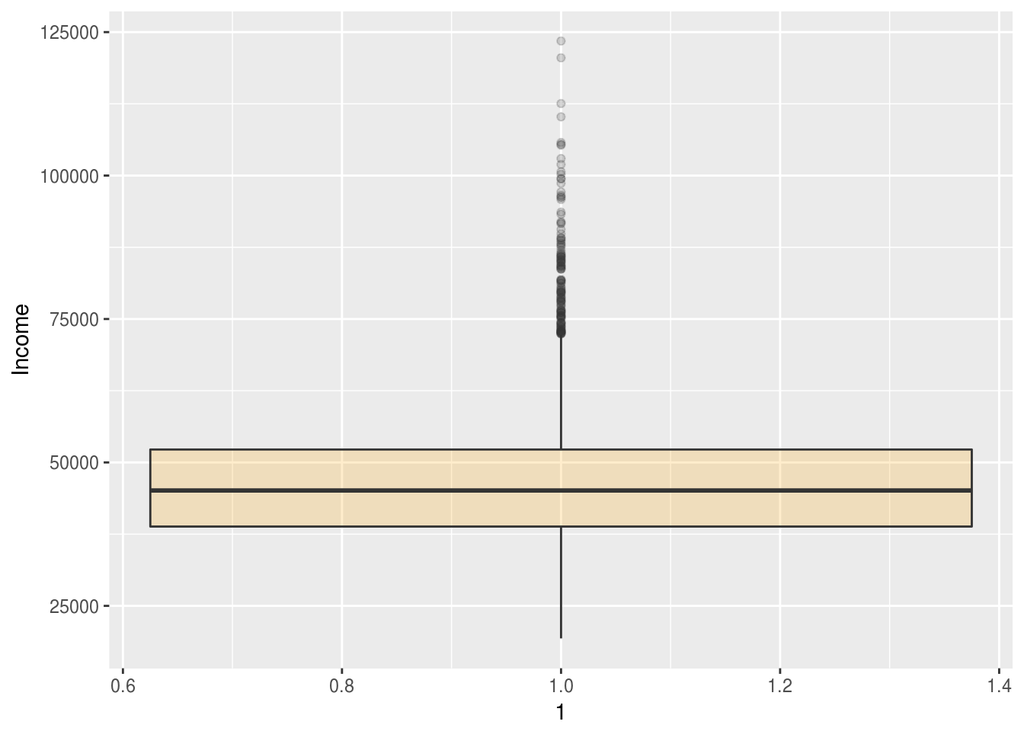

```r
ggplot(county_df, aes(y=Income, x=1)) + geom_boxplot(fill = "orange", alpha = 0.2)
```

# Kernel Density Plot

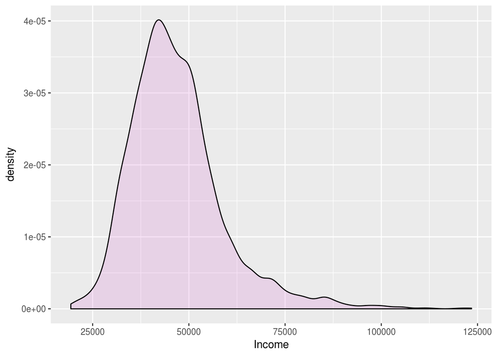

```r
library(ggplot2)
ggplot(county_df, aes(x=Income)) + geom_density(fill = "orchid", alpha = 0.2)
```

# Violin Plot

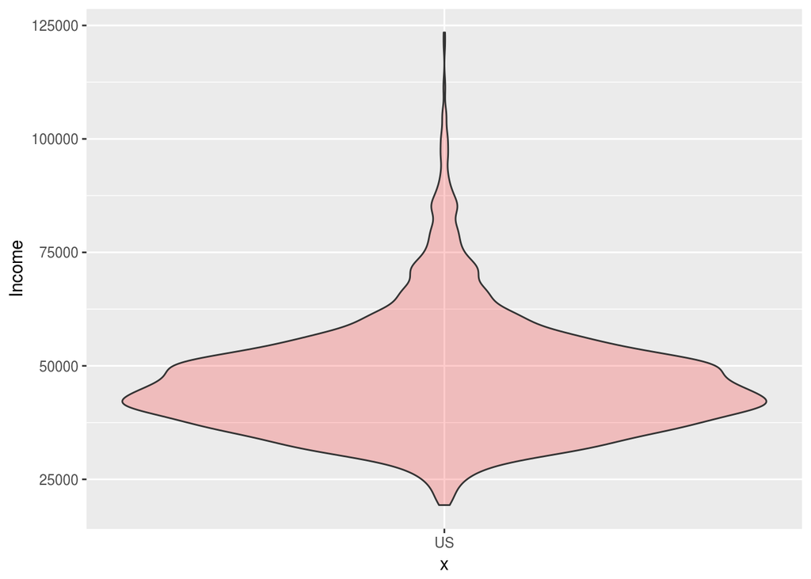

```r
ggplot(county_df, aes(x="US", y=Income)) + geom_violin(fill = "red", alpha = 0.2)
```

### Problem 3 - Histogram of total population

Create a histogram of total population for counties in the US.

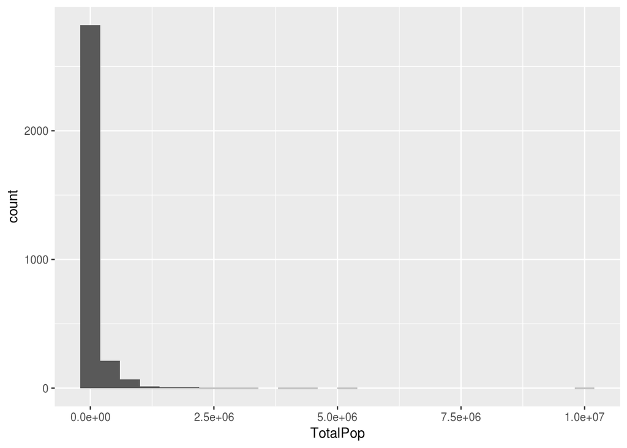

```r
ggplot(data = county_df) + geom_histogram(aes(x = TotalPop), binwidth = 400000)
```

Repeat the histogram about but make the following style changes to the plot.

- Add a title such as “Distribution of population for US counties”
- Change y-axis label to “Number of counties”
- Change x-axis label to “Total Population”
- Change the colors of the bars to something other than the default black

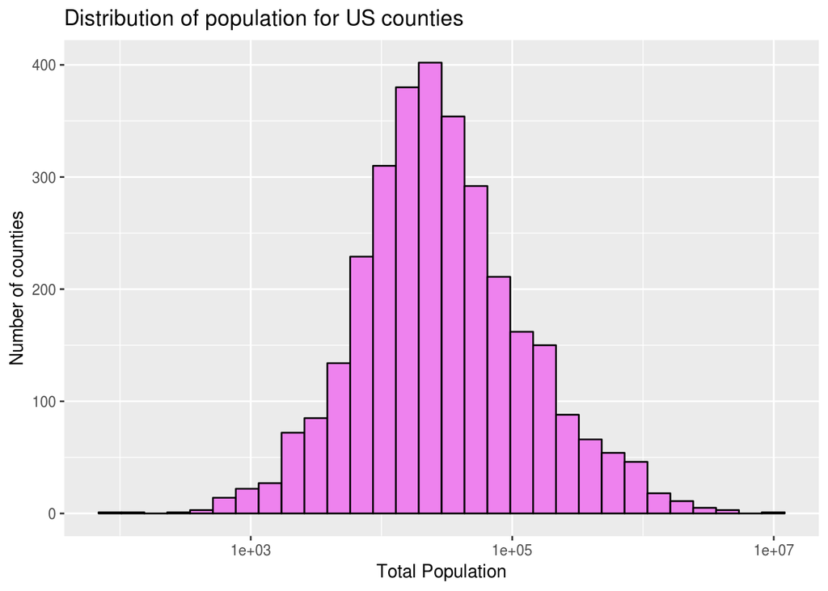

```r
library(ggplot2)
ggplot(data = county_df) + geom_histogram(aes(x = TotalPop), fill = "violet", color = "black") + labs(
    x = "Total Population",                                    # x axis title
    y = "Number of counties",                                  # y axis title
    title = "Distribution of population for US counties"       # main title of figure
  ) + scale_x_log10()
```

**Hacker Extra** - Also create a kernel density plot overlaid on a histogram of Income.

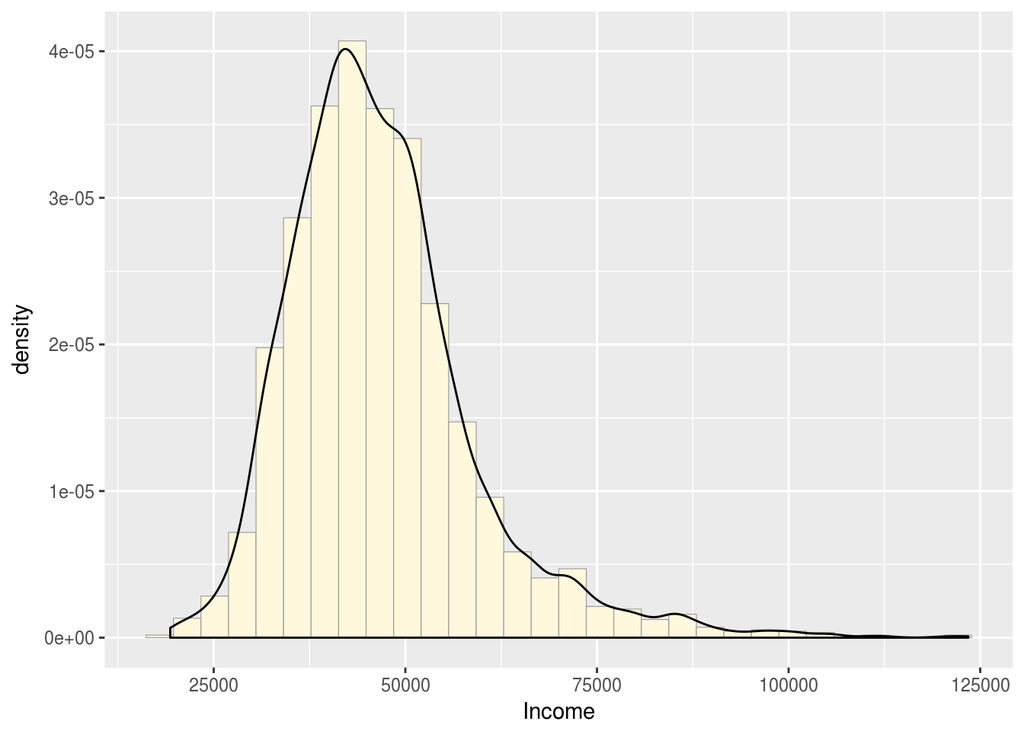

```r
ggplot(county_df, aes(x=Income, y=..density..)) + geom_histogram(fill="cornsilk", color="grey60", size=.2) + geom_density()
```

Repeat the histogram but only for counties with less than 2.5 million people.

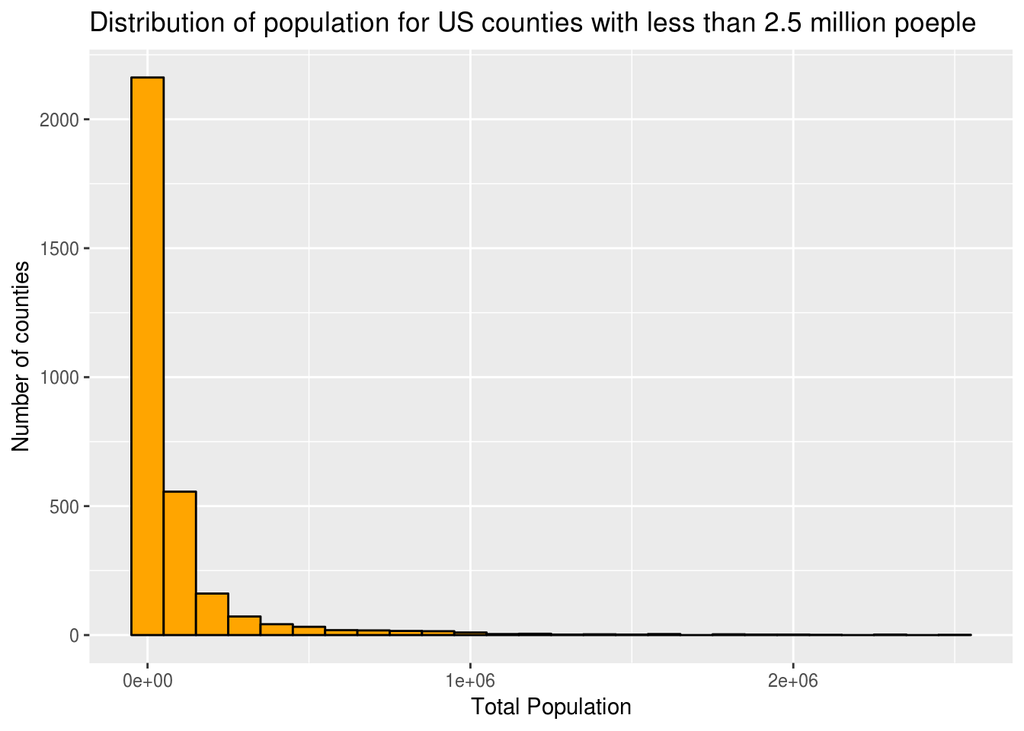

```r
# Created a dataframe with less than 2.5 million people
county_sub <-subset(county_df, TotalPop < 2500000)

# Calling data from the new data frame, county_sub with less than 2.5 million people
library(ggplot2)
ggplot(data = county_sub) + geom_histogram(aes(x = TotalPop), binwidth = 100000, fill = "orange", color = "black") + labs(
    x = "Total Population",                                                                      # x axis title
    y = "Number of counties",                                                                    # y axis title
    title = "Distribution of population for US counties with less than 2.5 million poeple"       # main title of figure
  )
```

### Problem 4 - How do Michigan’s peninsulas compare?

Create a grouped box plot showing Income by peninsula. Make sure your graph has a title and good axis labels.

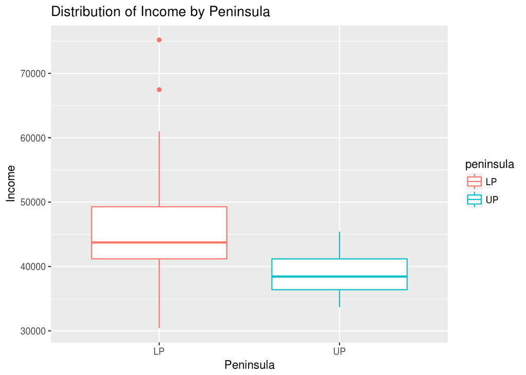

```r
ggplot(county_MI, aes(x=peninsula, y=Income, color=peninsula)) + geom_boxplot() + labs(
    x = "Peninsula",                                    # x axis title
    y = "Income",                                       # y axis title
    title = "Distribution of Income by Peninsula"       # main title of figure
  )
```

Do the peninsulas differ with respect to distribution of median income over the counties?

Yes, from the Boxplot as shown above, it looks like there is a significant difference in the distribution of median income in the peninsulas over the counties.

Create several more boxplots showing how the peninsulas compare with respect to some of the other variables. Summarize your findings in a few short paragraphs.

# i) Population Distribution Across Peninsula

The total population distribution for LP is higher than that of the UP. The Median of the Total Population distribution for Upper Peninsula is closer to the lower end of the spectrum for all of the population value and is closer to the end of the left whiskers (down whiskers) than to that of the end of the right whisker (top whiskers), indicating thin population distribution in Upper Peninsula as compared to that of the Lower Peninsula. On the other hand, the Median of the Total Population distribution is higher in Lower Peninsula as compared to that of the Upper Peninsula.

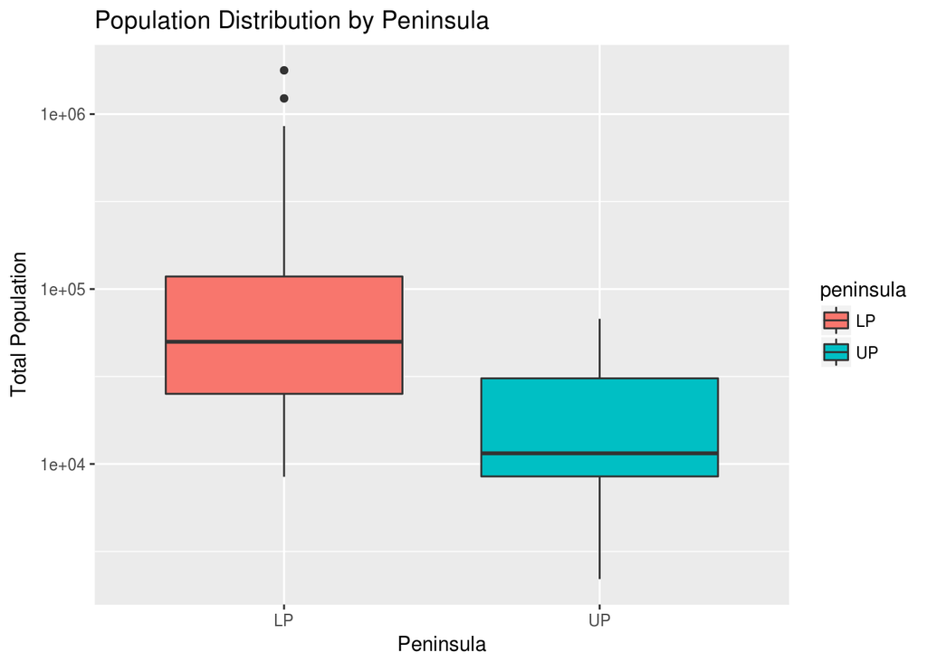

```r
ggplot(county_MI, aes(x=peninsula, y=TotalPop, fill=peninsula)) + geom_boxplot() + labs(
    x = "Peninsula",                                    # x axis title
    y = "Total Population",                             # y axis title
    title = "Population Distribution by Peninsula"      # main title of figure
) + scale_y_log10()
```

# ii) Poverty Distribution across Peninsula

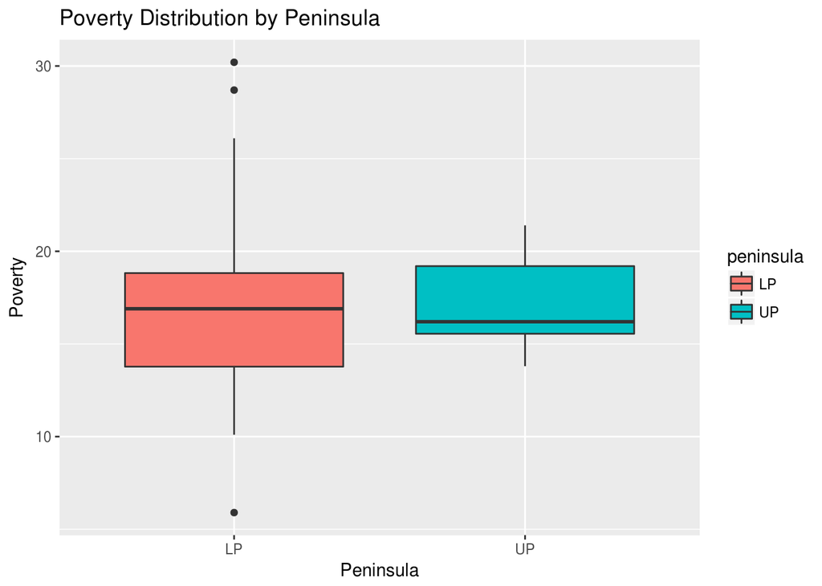

```r
ggplot(county_MI, aes(x=peninsula, y=Poverty, fill = peninsula)) + geom_boxplot() + labs(
    x = "Peninsula",                                    # x axis title
    y = "Poverty",                                      # y axis title
    title = "Poverty Distribution by Peninsula"         # main title of figure
)
```

# iii) Child Poverty Distribution across Peninsula

The Median of the Child Poverty Distribution for Upper Peninsula is at 25 and it goes around the middle of the entire spectrum of the boxplot. From the Box-plot it looks like all the Quartiles for the Upper Peninsula are uniformly and equally distributed. The Median of the Child Poverty Distribution for Lower Peninsula is slightly below 25 and the Median of the Child Poverty Distribution for the entire spectrum of the boxplot is towards the top whiskers (or the right whiskers).

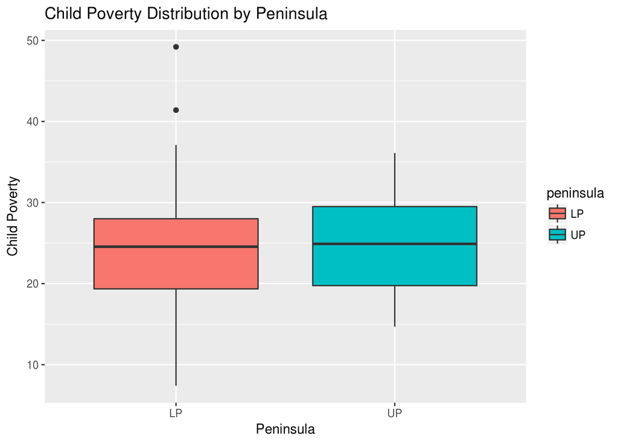

```r
ggplot(county_MI, aes(x=peninsula, y=ChildPoverty, fill = peninsula)) + geom_boxplot() + labs(
    x = "Peninsula",                                          # x axis title
    y = "Child Poverty",                                      # y axis title
    title = "Child Poverty Distribution by Peninsula"         # main title of figure
)
```

# iv) Income per capita Distribution by Peninsula

The Median of the Income Per Capita distribution across Upper Peninsula is lower than that of the Median of the Income per capita distribution in the Lower Peninsula. The Median of the Income per capita distribution for the Upper Peninsula is lower than the value of 22,500, while the Median of the Income per capita distribution for the Lower Peninsula is greater than the value of 22,500.

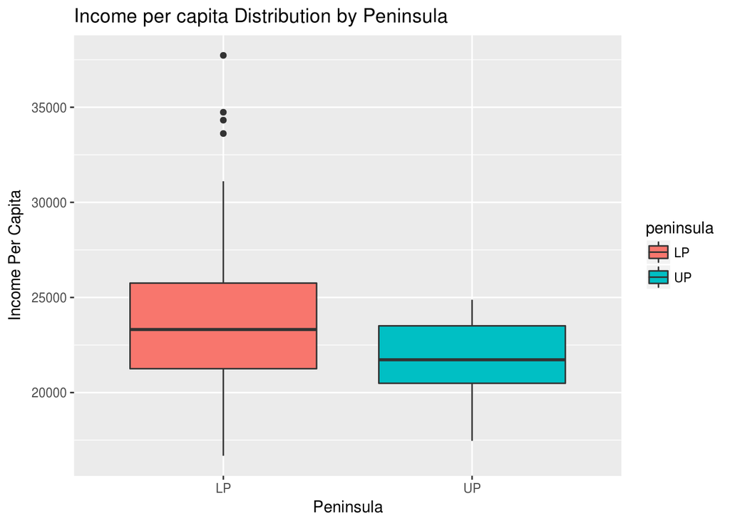

```r
ggplot(county_MI, aes(x=peninsula, y=IncomePerCap, fill = peninsula)) + geom_boxplot() + labs(
    x = "Peninsula",                                              # x axis title
    y = "Income Per Capita",                                      # y axis title
    title = "Income per capita Distribution by Peninsula"         # main title of figure
)
```

# v) Employment Distribution Across Peninsula

Considering the Employment distribution across both the Upper & the Lower Peninsula, it looks like the Median of the Employment Distribution for the Upper Peninsula is much lower as compared to that of the Lower Peninsula.

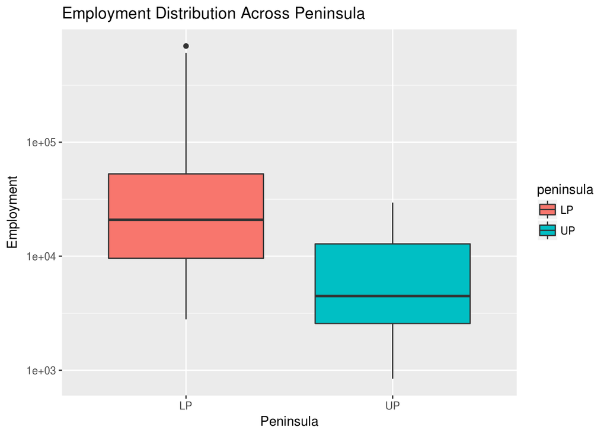

```r
ggplot(county_MI, aes(x=peninsula, y=Employed, fill = peninsula)) + geom_boxplot() + labs(
    x = "Peninsula",                                           # x axis title
    y = "Employment",                                          # y axis title
    title = "Employment Distribution Across Peninsula"         # main title of figure
) + scale_y_log10()
```

# vi) Unemployment Distribution Across Peninsula

The Median of the Unemployment Distribution across Upper Peninsula looks more towards the lower end of the down whisker (left whisker), within the entire spectrum of the Unemployment Distribution in Upper Peninsula. The Median of the Unemployment Distribution for Upper Peninsula is low as compared to the Median of the Unemployment Distribution for the Lower Peninsula. However, when compared to the Unemployment Distribution with the Lower Peninsula, the distribution of Unemployment in the Upper Peninsula appears to be more on a cummulative scale.

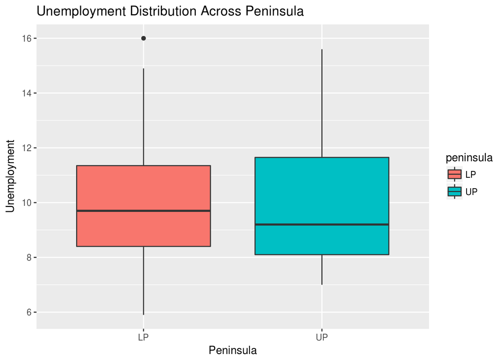

```r
ggplot(county_MI, aes(x=peninsula, y=Unemployment, fill = peninsula)) + geom_boxplot() + labs(
    x = "Peninsula",                                             # x axis title
    y = "Unemployment",                                          # y axis title
    title = "Unemployment Distribution Across Peninsula"         # main title of figure
)
```

# vii) Citizens Distribution Across Peninsula

The Median of the number of Citizen Distribution looks to be on the higher side for the Lower Peninsula as compared to that of the Upper Peninsula. The Median value of the Citizen Distribution is closer towards the lower end of the entire spectrum, for the Upper Peninsula. While the Median value of the Citizen Distribution across the Lower Peninsula seems to be little dragged towards the down whisker (left). The entire quartile for the citizens distribution across both the Upper Peninsula is smaller as compared to that of the Lower Peninsula.

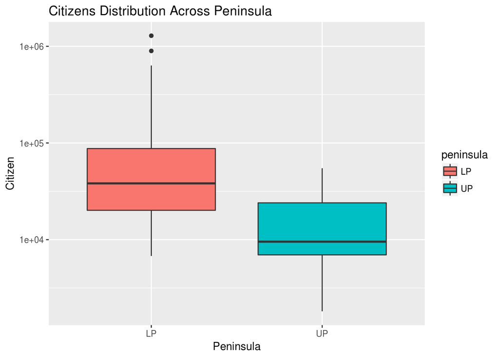

```r
ggplot(county_MI, aes(x=peninsula, y=Citizen, fill = peninsula)) + geom_boxplot() + labs(
    x = "Peninsula",                                         # x axis title
    y = "Citizen",                                           # y axis title
    title = "Citizens Distribution Across Peninsula"         # main title of figure
) + scale_y_log10()
```

# viii) Number of Men & Women Across the Peninsula

The Median of the number of Men across the Upper Peninsula seems to be more closer towards the down whisker (left whisker). The Median of the number of Men across the Lower Peninsula seems to be little inclined towards the down whisker (left whisker).The entire quartile for the distribution of the number of Men is more in Lower Peninsula as compared to that of the Upper Peninsula.

The Median of the number of Women across the Upper Peninsula seems to be more closer towards the down whisker (left whisker). The Median of the number of Women across the Lower Peninsula seems to be little inclined towards the down whisker (left whisker).The entire quartile for the distribution of the number of Women is more in Lower Peninsula as compared to that of the Upper Peninsula.

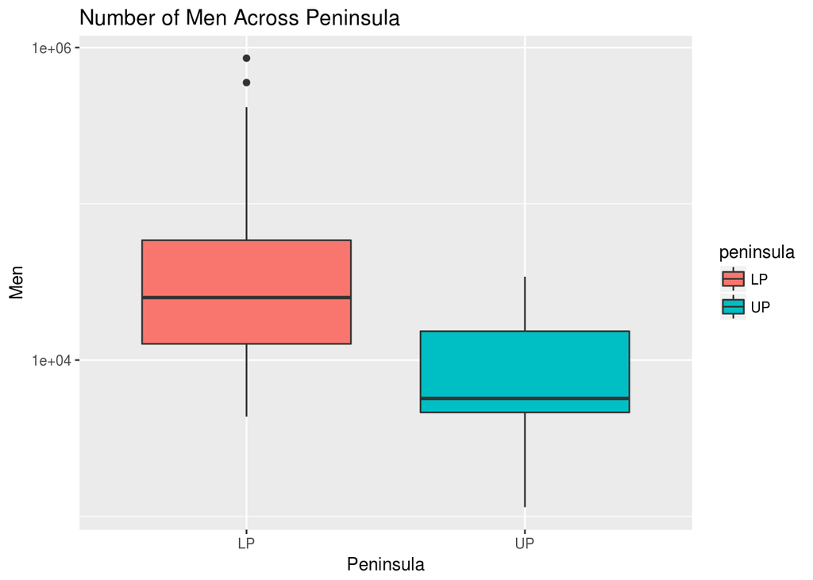

```r
# Number of Men
ggplot(county_MI, aes(x=peninsula, y=Men, fill = peninsula)) + geom_boxplot() + labs(
    x = "Peninsula",                                    # x axis title
    y = "Men",                                          # y axis title
    title = "Number of Men Across Peninsula"            # main title of figure
) + scale_y_log10()
```

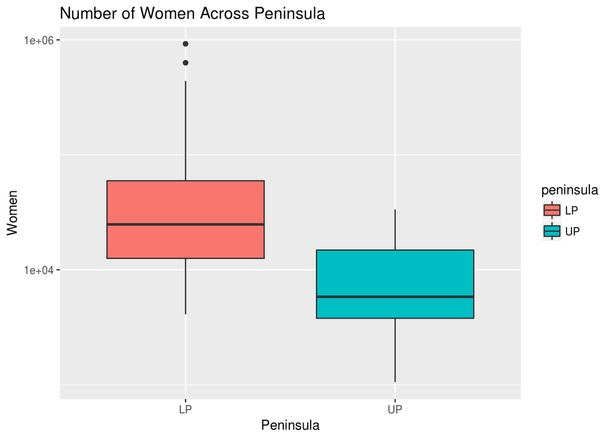

```r
# Number of Women
ggplot(county_MI, aes(x=peninsula, y=Women, fill = peninsula)) + geom_boxplot() + labs(
    x = "Peninsula",                                   # x axis title
    y = "Women",                                       # y axis title
    title = "Number of Women Across Peninsula"         # main title of figure
) + scale_y_log10()
```

# ix) Mean Commute Time Across Peninsula

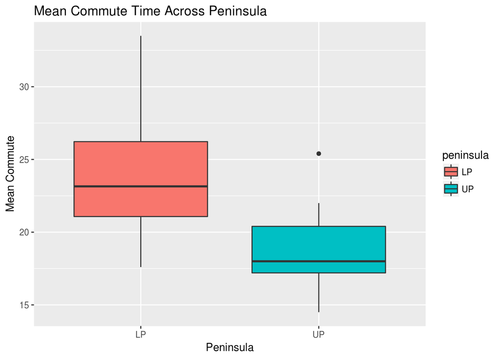

```r
ggplot(county_MI, aes(x=peninsula, y=MeanCommute, fill = peninsula)) + geom_boxplot() + labs(
    x = "Peninsula",                                     # x axis title
    y = "Mean Commute",                                  # y axis title
    title = "Mean Commute Time Across Peninsula"         # main title of figure
)
```

### Problem 5 - How do regions of the country compare?

In county_df you’ll see that there’s a Region field. Create a set of faceted histograms showing how some variable of interest to you compares by region. For example, you could explore how the regions compare with respect to the distribution of MeanCommute time. Make sure your graph has a title and good axis labels.

# Mean Commute Time Across Various Regions

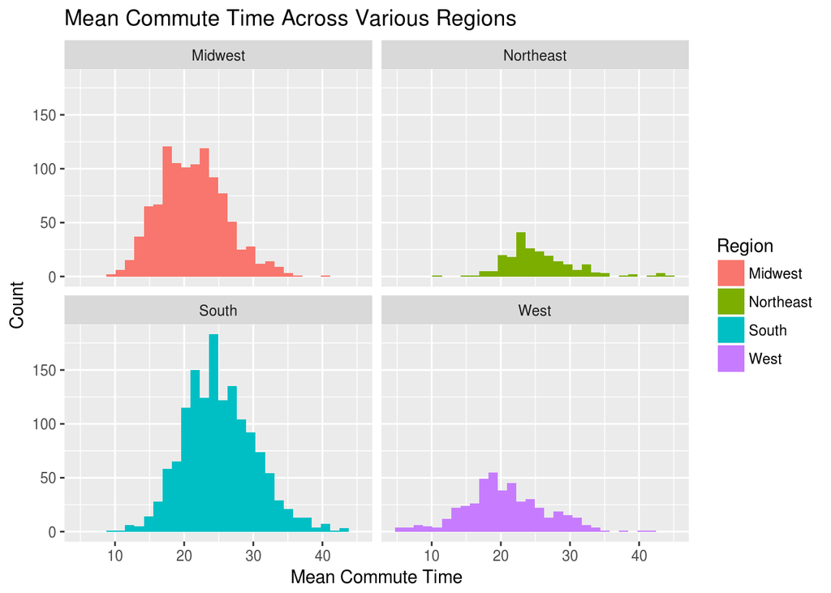

```r
ggplot(county_df, aes(x=MeanCommute, fill = Region)) + geom_histogram() + labs(
    x = "Mean Commute Time",                                   # x axis title
    y = "Count",                                               # y axis title
    title = "Mean Commute Time Across Various Regions"         # main title of figure
) + facet_wrap(~Region)
```

# Total Population Distribution & Distribution of Population By Gender

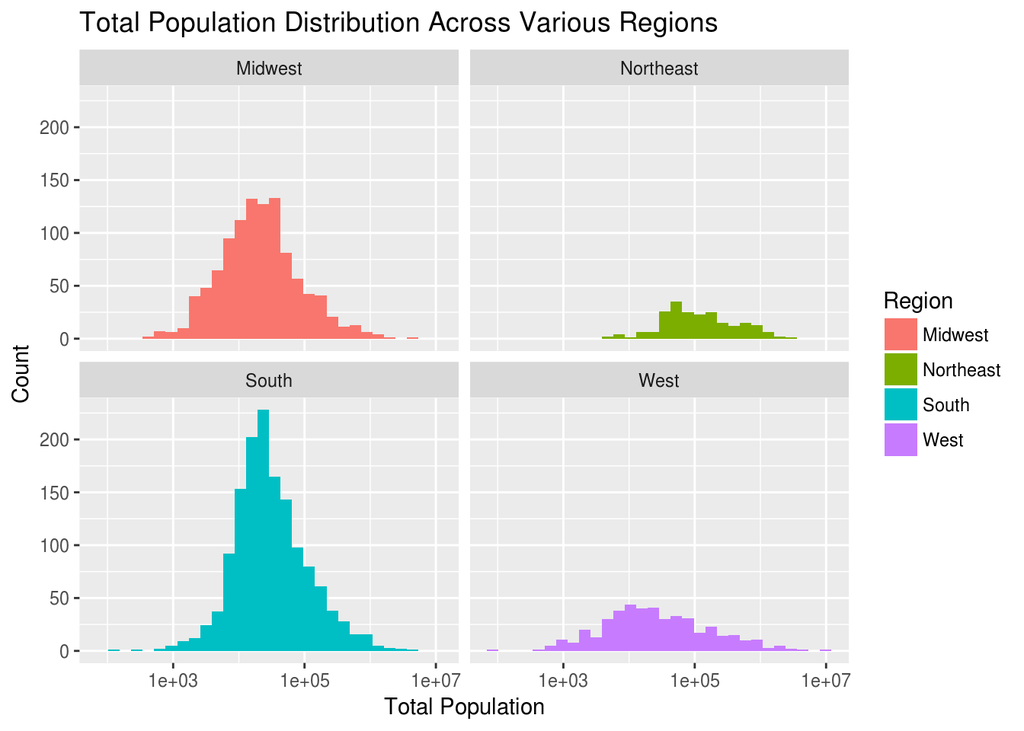

```r
# Featured Engineering of PercentageMen & PercentageWomen
county_df$PercentageMen <- (county_df$Men/county_df$TotalPop)*100
county_df$PercentageWomen <- (county_df$Women/county_df$TotalPop)*100

# Dropping a Column added by mistake
county_df$PercentageMale <- NULL

# Total Population Distribution
ggplot(county_df, aes(x=TotalPop, fill = Region), binwidth = 300000) + geom_histogram() + labs(
    x = "Total Population",                                                # x axis title
    y = "Count",                                                           # y axis title
    title = "Total Population Distribution Across Various Regions"         # main title of figure
) + facet_wrap(~Region) + scale_x_log10()
```

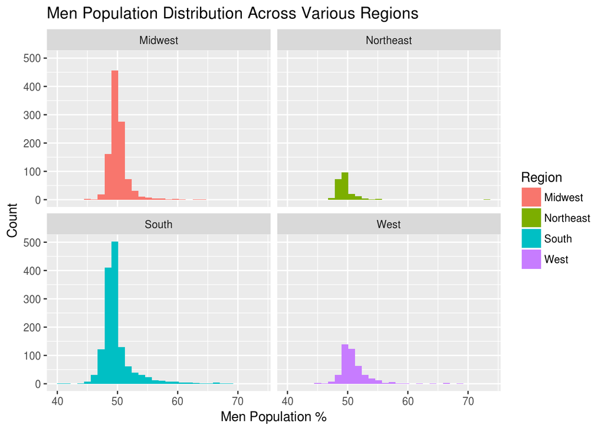

```r
# Percentage of Men Across Total Population Distribution
ggplot(county_df, aes(x=PercentageMen, fill = Region), binwidth = 300000) + geom_histogram() + labs(
    x = "Men Population %",                                               # x axis title
    y = "Count",                                                          # y axis title
    title = "Men Population Distribution Across Various Regions"          # main title of figure
) + facet_wrap(~Region)
```

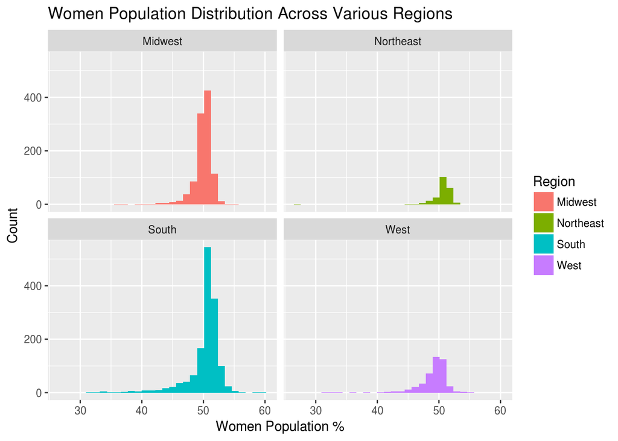

```r
# Percentage of Women Across Total Population Distribution
ggplot(county_df, aes(x=PercentageWomen, fill = Region), binwidth = 300000) + geom_histogram() + labs(
    x = "Women Population %",                                              # x axis title
    y = "Count",                                                           # y axis title
    title = "Women Population Distribution Across Various Regions"         # main title of figure
) + facet_wrap(~Region)
```

### Problem 6 - Basic bar chart

Create a bar chart showing the number of counties by Region in the US. Make sure your graph has a title and good axis labels.

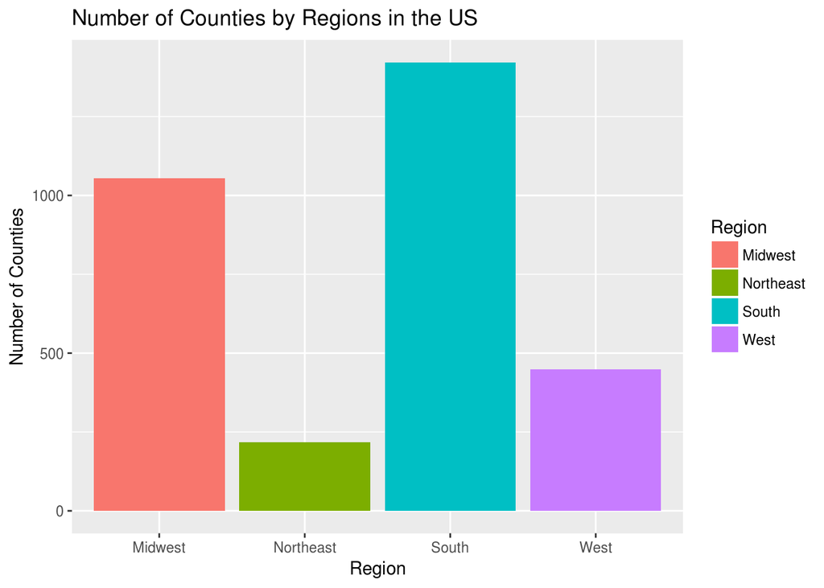

```r
library(reshape2)
ggplot(data=county_df, aes(x=Region, fill = Region)) +
    geom_bar(stat="count") + labs(
    x = "Region",                                             # x axis title
    y = "Number of Counties",                                 # y axis title
    title = "Number of Counties by Regions in the US"         # main title of figure
)
```

### Problem 7 - Basic scatter plots

Create a scatter plot using the Michigan only data frame comparing Income and MeanCommute.

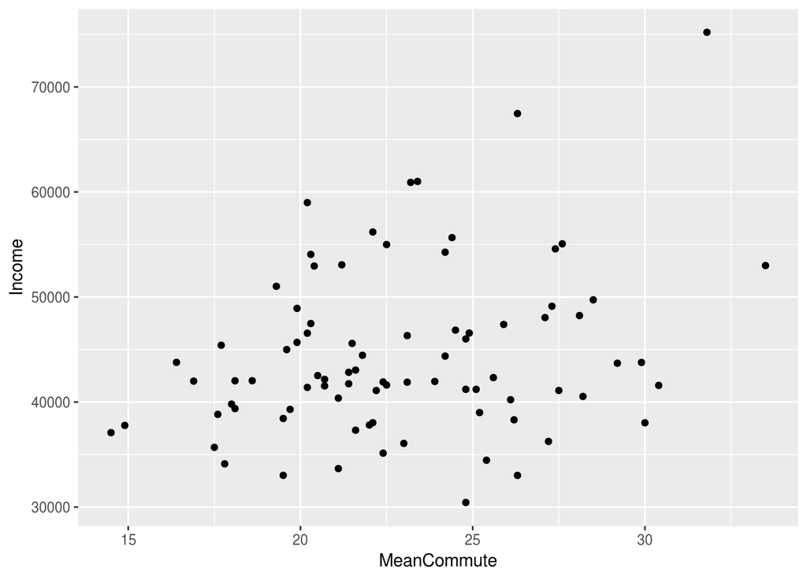

```r
ggplot(data = county_MI, aes(x = MeanCommute, y = Income)) + geom_point()
```

Create a modified version of the above scatter plot in which the point color is mapped to peninsula.

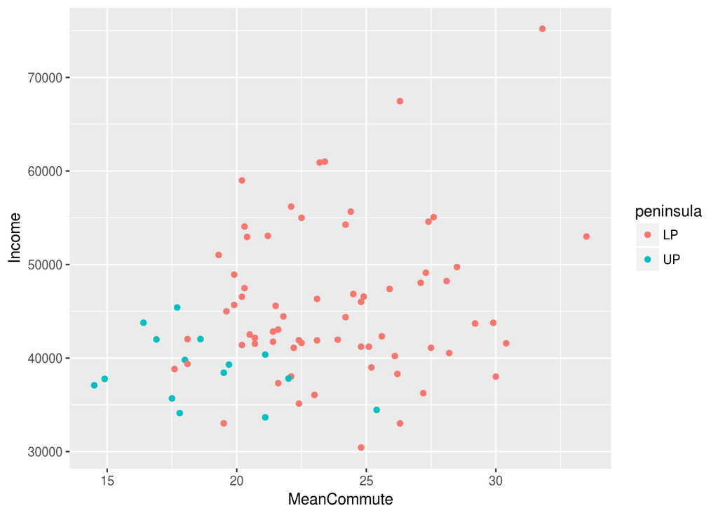

```r
ggplot(county_MI, aes(MeanCommute, Income, color = peninsula)) + geom_point()
```

Your thoughts on the relationship between these variables?

From the Scatterplots of the two variables Income & MeanCommute, we can see random scatter where each point in the data sets represent the corresponding value of the Income for a given Mean Commute Time and vice versa. It looks like the data points produce a pattern from left to right with some data points for the Lower Peninsula as Outliers. Overall, from the Sctterplots visuals it seems like the variables Income and the Mean Commute Time has a weak correlation betwen each other.

Now, create a few more scatter plots using variables of your choosing in which you facet by peninsula as well. How do the relationships compare across the peninsulas?

# i) Scatterplots of Total Population by Income Across the Peninsula

From the Scatterplots of the two variables, Total Population and the Income it looks like that there is a weak correlation between the Total Population and the Income across both the Upper and Lower Peninsula.

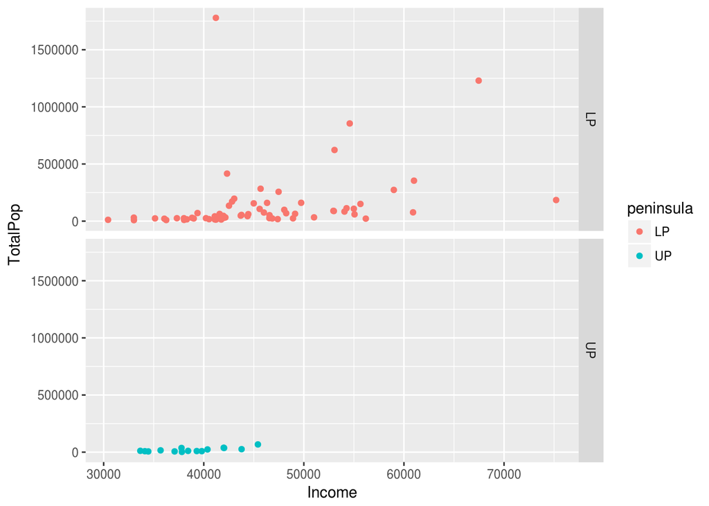

```r
ggplot(county_MI, aes(Income, TotalPop, color = peninsula)) +
geom_point() + facet_grid(peninsula ~ .)
```

# ii) Scatterplots of Total Population by Citizen Across the Peninsula

From the Scatterplots of the two variables Total Population and the Citizen, there seems to be a steady slope between these two variables Total Population and Citizen. Hence, we can say that these two variables Total Population and Citizen have a Positive Correlation or in other words these two variables have a Strong Correlation between each other across both the Upper & Lower Peninsula in Michigan.

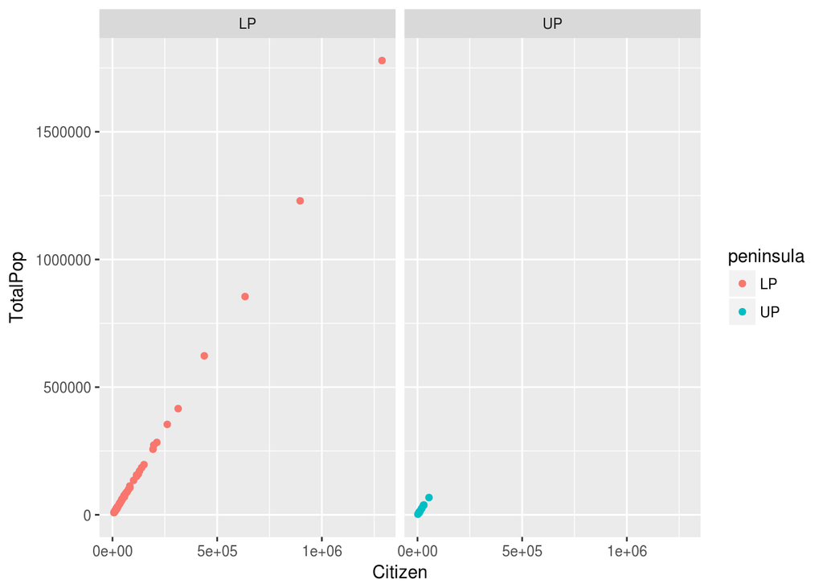

```r
ggplot(county_MI, aes(Citizen, TotalPop, color = peninsula)) +
geom_point() + facet_grid(. ~ peninsula)
```